# Developing an AI application

Going forward, AI algorithms will be incorporated into more and more everyday applications. For example, you might want to include an image classifier in a smart phone app. To do this, you'd use a deep learning model trained on hundreds of thousands of images as part of the overall application architecture. A large part of software development in the future will be using these types of models as common parts of applications.

In this project, you'll train an image classifier to recognize different species of flowers. You can imagine using something like this in a phone app that tells you the name of the flower your camera is looking at. In practice you'd train this classifier, then export it for use in your application. We'll be using [this dataset](http://www.robots.ox.ac.uk/~vgg/data/flowers/102/index.html) of 102 flower categories, you can see a few examples below.

[figure not shown]

The project is broken down into multiple steps:

- Load and preprocess the image dataset
- Train the image classifier on your dataset
- Use the trained classifier to predict image content

We'll lead you through each part which you'll implement in Python.

When you've completed this project, you'll have an application that can be trained on any set of labeled images. Here your network will be learning about flowers and end up as a command line application. But, what you do with your new skills depends on your imagination and effort in building a dataset. For example, imagine an app where you take a picture of a car, it tells you what the make and model is, then looks up information about it. Go build your own dataset and make something new.

First up is importing the packages you'll need. It's good practice to keep all the imports at the beginning of your code. As you work through this notebook and find you need to import a package, make sure to add the import up here.

```python
# Imports here

## Imports to load the data
from torchvision import datasets, transforms
import torch
import json

## Imports to build and train the model
from torchvision import models
from torch import nn, optim
import torch.nn.functional as F

##Imports for image processing
from PIL import Image
import matplotlib.pyplot as plt
import numpy as np
```

## Load the data

Here you'll use `torchvision` to load the data ([documentation](http://pytorch.org/docs/0.3.0/torchvision/index.html)). The data should be included alongside this notebook, otherwise you can [download it here](https://s3.amazonaws.com/content.udacity-data.com/nd089/flower_data.tar.gz). The dataset is split into three parts, training, validation, and testing. For the training, you'll want to apply transformations such as random scaling, cropping, and flipping. This will help the network generalize leading to better performance. You'll also need to make sure the input data is resized to 224x224 pixels as required by the pre-trained networks.

The validation and testing sets are used to measure the model's performance on data it hasn't seen yet. For this you don't want any scaling or rotation transformations, but you'll need to resize then crop the images to the appropriate size.

The pre-trained networks you'll use were trained on the ImageNet dataset where each color channel was normalized separately. For all three sets you'll need to normalize the means and standard deviations of the images to what the network expects. For the means, it's `[0.485, 0.456, 0.406]` and for the standard deviations `[0.229, 0.224, 0.225]`, calculated from the ImageNet images. These values will shift each color channel to be centered at 0 and range from -1 to 1.

```python
data_dir = 'flowers'
train_dir = data_dir + '/train'
valid_dir = data_dir + '/valid'
test_dir = data_dir + '/test'
```

```python
# TODO: Define your transforms for the training, validation, and testing sets

## The transforms for the training dataset include random rotation, flip and resize/crop as well as normalization
## The PIL image is converted into a Tensor
train_data_transforms = transforms.Compose([transforms.RandomRotation(25),
                                      transforms.RandomResizedCrop(224),
                                      transforms.RandomHorizontalFlip(),
                                      transforms.ToTensor(),
                                      transforms.Normalize([0.485, 0.456, 0.406],
                                                          [0.229, 0.224, 0.225])])

## The transforms for bothe the testing and validation sets are the same
## They do not involve flipping or rotation, but resize/crop and normalzation
## The PIL image is converted into a Tensor
test_data_transforms = transforms.Compose([transforms.Resize(255),
                                           transforms.CenterCrop(224),
                                           transforms.ToTensor(),
                                           transforms.Normalize([0.485, 0.456, 0.406],
                                                                [0.229, 0.224, 0.225])])


# TODO: Load the datasets with ImageFolder
train_image_datasets = datasets.ImageFolder(data_dir + '/train', transform=train_data_transforms)
test_image_datasets = datasets.ImageFolder(data_dir + '/test', transform=test_data_transforms)
valid_image_datasets = datasets.ImageFolder(data_dir + '/valid', transform=test_data_transforms)

# TODO: Using the image datasets and the trainforms, define the dataloaders

## We choose a batch size of 64 images
## To train the model, we want the images to be randomly chosen (shuffle=True), as the model will have a propency to learn better
## It is not the case for the testing and validation datasets
train_dataloaders = torch.utils.data.DataLoader(train_image_datasets, batch_size=64, shuffle=True)
test_dataloaders = torch.utils.data.DataLoader(test_image_datasets, batch_size=64)
valid_dataloaders = torch.utils.data.DataLoader(valid_image_datasets, batch_size=64)
```

### Label mapping

You'll also need to load in a mapping from category label to category name. You can find this in the file `cat_to_name.json`. It's a JSON object which you can read in with the [`json` module](https://docs.python.org/2/library/json.html). This will give you a dictionary mapping the integer encoded categories to the actual names of the flowers.

```python
#import json

with open('cat_to_name.json', 'r') as f:
    cat_to_name = json.load(f)
```

# Building and training the classifier

Now that the data is ready, it's time to build and train the classifier. As usual, you should use one of the pretrained models from `torchvision.models` to get the image features. Build and train a new feed-forward classifier using those features.

We're going to leave this part up to you. Refer to [the rubric](https://review.udacity.com/#!/rubrics/1663/view) for guidance on successfully completing this section. Things you'll need to do:

- Load a [pre-trained network](http://pytorch.org/docs/master/torchvision/models.html) (If you need a starting point, the VGG networks work great and are straightforward to use)
- Define a new, untrained feed-forward network as a classifier, using ReLU activations and dropout
- Train the classifier layers using backpropagation using the pre-trained network to get the features
- Track the loss and accuracy on the validation set to determine the best hyperparameters

We've left a cell open for you below, but use as many as you need. Our advice is to break the problem up into smaller parts you can run separately. Check that each part is doing what you expect, then move on to the next. You'll likely find that as you work through each part, you'll need to go back and modify your previous code. This is totally normal!

When training make sure you're updating only the weights of the feed-forward network. You should be able to get the validation accuracy above 70% if you build everything right. Make sure to try different hyperparameters (learning rate, units in the classifier, epochs, etc) to find the best model. Save those hyperparameters to use as default values in the next part of the project.

One last important tip if you're using the workspace to run your code: To avoid having your workspace disconnect during the long-running tasks in this notebook, please read in the earlier page in this lesson called Intro to GPU Workspaces about Keeping Your Session Active. You'll want to include code from the workspace_utils.py module.

**Note for Workspace users:** If your network is over 1 GB when saved as a checkpoint, there might be issues with saving backups in your workspace. Typically this happens with wide dense layers after the convolutional layers. If your saved checkpoint is larger than 1 GB (you can open a terminal and check with `ls -lh`), you should reduce the size of your hidden layers and train again.

```python
# TODO: Build and train your network

## Before starting to build and train the model, we add this command to be able to use the GPU if available
device = torch.device("cuda" if torch.cuda.is_available() else "cpu")
## Note: we will have to remember to move the model and the data to "device" to be able to run our code
```

```python
##First step, we create our model from a pretrained model from torchvision
## We choose to use the pretrained model VGG-16 as its overall performance is good without requiring too many layers
model = models.vgg16(pretrained=True)

## We look at the details of this pretrained model, in particular to see the details of its default classifier
model
```

```
VGG(
  (features): Sequential(
    (0): Conv2d(3, 64, kernel_size=(3, 3), stride=(1, 1), padding=(1, 1))
    (1): ReLU(inplace)
    (2): Conv2d(64, 64, kernel_size=(3, 3), stride=(1, 1), padding=(1, 1))
    (3): ReLU(inplace)
    (4): MaxPool2d(kernel_size=2, stride=2, padding=0, dilation=1, ceil_mode=False)
    (5): Conv2d(64, 128, kernel_size=(3, 3), stride=(1, 1), padding=(1, 1))
    (6): ReLU(inplace)
    (7): Conv2d(128, 128, kernel_size=(3, 3), stride=(1, 1), padding=(1, 1))
    (8): ReLU(inplace)
    (9): MaxPool2d(kernel_size=2, stride=2, padding=0, dilation=1, ceil_mode=False)
    (10): Conv2d(128, 256, kernel_size=(3, 3), stride=(1, 1), padding=(1, 1))
    (11): ReLU(inplace)
    (12): Conv2d(256, 256, kernel_size=(3, 3), stride=(1, 1), padding=(1, 1))
    (13): ReLU(inplace)
    (14): Conv2d(256, 256, kernel_size=(3, 3), stride=(1, 1), padding=(1, 1))
    (15): ReLU(inplace)
    (16): MaxPool2d(kernel_size=2, stride=2, padding=0, dilation=1, ceil_mode=False)
    (17): Conv2d(256, 512, kernel_size=(3, 3), stride=(1, 1), padding=(1, 1))
    (18): ReLU(inplace)
    (19): Conv2d(512, 512, kernel_size=(3, 3), stride=(1, 1), padding=(1, 1))
    (20): ReLU(inplace)
    (21): Conv2d(512, 512, kernel_size=(3, 3), stride=(1, 1), padding=(1, 1))
    (22): ReLU(inplace)
    (23): MaxPool2d(kernel_size=2, stride=2, padding=0, dilation=1, ceil_mode=False)
    (24): Conv2d(512, 512, kernel_size=(3, 3), stride=(1, 1), padding=(1, 1))
    (25): ReLU(inplace)
    (26): Conv2d(512, 512, kernel_size=(3, 3), stride=(1, 1), padding=(1, 1))
    (27): ReLU(inplace)
    (28): Conv2d(512, 512, kernel_size=(3, 3), stride=(1, 1), padding=(1, 1))
    (29): ReLU(inplace)
    (30): MaxPool2d(kernel_size=2, stride=2, padding=0, dilation=1, ceil_mode=False)
  )
  (classifier): Sequential(
    (0): Linear(in_features=25088, out_features=4096, bias=True)
    (1): ReLU(inplace)
    (2): Dropout(p=0.5)
    (3): Linear(in_features=4096, out_features=4096, bias=True)
    (4): ReLU(inplace)
    (5): Dropout(p=0.5)
    (6): Linear(in_features=4096, out_features=1000, bias=True)
  )
)
```

```python
## We see that the classifier of the pretrained network VGG-16 has two hidden layers with ReLU activation functions
# and one output layer without activation function, that returns values for 1000 classes
## We are going to "freeze" the features, and use a different classifier, which input will still be of size 25088
## The reason is that we do not need to work with 1000 classes (model pretrained on ImageNet with 1000 classes), but
# we only have 102 categories of flowers to classify

## Freeze the parameters, by turning off gradient descent
# (no backpropagation on the features layers, only on the classifier)
for param in model.parameters():
    param.requires_grad = False

## We define a new classifier from nn.Module
## We decide to keep the same number of layers as the initial pretrained model
## we use ReLU for the hidden layers and LogSoftmax for the output layer

class Classifier(nn.Module):
    def __init__(self):
        super().__init__()
        self.fc1 = nn.Linear(25088, 256) #hidden_layer_1 with same input as first layer of VGG classifier
        self.fc2 = nn.Linear(256, 128) #hidden_layer_2
        self.fc3 = nn.Linear(128, 102) #output layer with 102 classes

        # Dropout module with 0.2 drop probability
        self.dropout = nn.Dropout(p=0.2)

    def forward(self, x):
        x = F.relu(self.fc1(x))
        x = F.relu(self.fc2(x))
        x = F.log_softmax(self.fc3(x), dim=1)

        return x

## We replace the classifier used by our model
model.classifier = Classifier()

## We define the criterion using NLLoss because the output activation of the classifier is LogSoftmax
criterion = nn.NLLLoss()

## We define the optimizer to only train the classifier parameters, the feature parameters are frozen
optimizer = optim.SGD(model.classifier.parameters(), lr=0.003)

# We move our model to the GPU if available
model.to(device)

## We verify here that our new model uses the classifier we defined
```

```
VGG(
  (features): Sequential(
    (0): Conv2d(3, 64, kernel_size=(3, 3), stride=(1, 1), padding=(1, 1))
    (1): ReLU(inplace)
    (2): Conv2d(64, 64, kernel_size=(3, 3), stride=(1, 1), padding=(1, 1))
    (3): ReLU(inplace)
    (4): MaxPool2d(kernel_size=2, stride=2, padding=0, dilation=1, ceil_mode=False)
    (5): Conv2d(64, 128, kernel_size=(3, 3), stride=(1, 1), padding=(1, 1))
    (6): ReLU(inplace)
    (7): Conv2d(128, 128, kernel_size=(3, 3), stride=(1, 1), padding=(1, 1))
    (8): ReLU(inplace)
    (9): MaxPool2d(kernel_size=2, stride=2, padding=0, dilation=1, ceil_mode=False)
    (10): Conv2d(128, 256, kernel_size=(3, 3), stride=(1, 1), padding=(1, 1))
    (11): ReLU(inplace)
    (12): Conv2d(256, 256, kernel_size=(3, 3), stride=(1, 1), padding=(1, 1))
    (13): ReLU(inplace)
    (14): Conv2d(256, 256, kernel_size=(3, 3), stride=(1, 1), padding=(1, 1))
    (15): ReLU(inplace)
    (16): MaxPool2d(kernel_size=2, stride=2, padding=0, dilation=1, ceil_mode=False)
    (17): Conv2d(256, 512, kernel_size=(3, 3), stride=(1, 1), padding=(1, 1))
    (18): ReLU(inplace)
    (19): Conv2d(512, 512, kernel_size=(3, 3), stride=(1, 1), padding=(1, 1))
    (20): ReLU(inplace)
    (21): Conv2d(512, 512, kernel_size=(3, 3), stride=(1, 1), padding=(1, 1))
    (22): ReLU(inplace)
    (23): MaxPool2d(kernel_size=2, stride=2, padding=0, dilation=1, ceil_mode=False)
    (24): Conv2d(512, 512, kernel_size=(3, 3), stride=(1, 1), padding=(1, 1))
    (25): ReLU(inplace)
    (26): Conv2d(512, 512, kernel_size=(3, 3), stride=(1, 1), padding=(1, 1))
    (27): ReLU(inplace)
    (28): Conv2d(512, 512, kernel_size=(3, 3), stride=(1, 1), padding=(1, 1))
    (29): ReLU(inplace)
    (30): MaxPool2d(kernel_size=2, stride=2, padding=0, dilation=1, ceil_mode=False)
  )
  (classifier): Classifier(
    (fc1): Linear(in_features=25088, out_features=256, bias=True)
    (fc2): Linear(in_features=256, out_features=128, bias=True)
    (fc3): Linear(in_features=128, out_features=102, bias=True)
    (dropout): Dropout(p=0.2)
  )
)
```

```python
## Now that we have defined our model, we are going to train and validate it
## For readability and reusability, we define a few functions that we will use to train and test the model

def stage_model(dataset, loop_type):
    stage_loss = 0
    for images, labels in dataset:
        ## We move the data to the GPU if available
        images, labels = images.to(device), labels.to(device)
        if loop_type == 'train':
            ## Set back the gradient to 0 for each new epoch
            optimizer.zero_grad()
            ## Increment the stage_loss counter with the value of the loss at each epoch
            stage_loss += calc_loss(apply_model(images), labels)
            ## Use the optimizer to apply corrections on the weights and bias
            optimizer.step()
        else:
            stage_loss += calc_loss(apply_model(images), labels)

    return stage_loss


def calculate_accuracy(dataset):
    accuracy = 0
    for images, labels in dataset:
        ## We move the data to the GPU if available
        images, labels = images.to(device), labels.to(device)

        ## The output of the model is log, so to get probabilities we use the exponential function
        output = torch.exp(apply_model(images))

        ## We want to use only the top probability and top classes
        top_p, top_class = output.topk(1, dim=1)
        equals = top_class == labels.view(*top_class.shape)

        ## We use the mean of the distribution to determine the accuracy
        accuracy += torch.mean(equals.type(torch.FloatTensor)).item()
    return accuracy


def apply_model(image):
    ## Apply our model to the input images
    model_output = model(image)
    return model_output


def calc_loss(output, label):
    ## Calculate the loss and apply backpropagation
    loss = criterion(output, label)
    loss.backward()
    return loss


## We will train our network with 40 epochs
epochs = 50
steps = 0

for e in range(epochs):

    ## First we train the model on the train_dataloaders dataset
    training_loss = stage_model(train_dataloaders, 'train')

    ## Then we test our model on the testing set
    ## To increase the speed of this part of the code, we turn off dropout (as we do not need it for testing), using the model.eval() mode
    model.eval()
    testing_loss = stage_model(test_dataloaders, 'test')
    accuracy = calculate_accuracy(test_dataloaders)

    model.train()

    ## At each epoch, we print the performance metrics
    print("Epoch: {}/{}.. ".format(e+1, epochs),
          "Training Loss: {:.3f}.. ".format(training_loss/len(train_dataloaders)),
          "Test Loss: {:.3f}.. ".format(testing_loss/len(test_dataloaders)),
          "Test Accuracy: {:.3f}".format(accuracy/len(test_dataloaders)))
```

```
Epoch: 1/50..  Training Loss: 4.580..  Test Loss: 4.475..  Test Accuracy: 0.064
Epoch: 2/50..  Training Loss: 4.422..  Test Loss: 4.230..  Test Accuracy: 0.135
Epoch: 3/50..  Training Loss: 4.193..  Test Loss: 3.902..  Test Accuracy: 0.182
Epoch: 4/50..  Training Loss: 3.907..  Test Loss: 3.559..  Test Accuracy: 0.213
Epoch: 5/50..  Training Loss: 3.604..  Test Loss: 3.213..  Test Accuracy: 0.299
Epoch: 6/50..  Training Loss: 3.317..  Test Loss: 2.894..  Test Accuracy: 0.367
Epoch: 7/50..  Training Loss: 3.029..  Test Loss: 2.591..  Test Accuracy: 0.453
Epoch: 8/50..  Training Loss: 2.745..  Test Loss: 2.299..  Test Accuracy: 0.507
Epoch: 9/50..  Training Loss: 2.490..  Test Loss: 2.046..  Test Accuracy: 0.555
Epoch: 10/50..  Training Loss: 2.265..  Test Loss: 1.861..  Test Accuracy: 0.587
Epoch: 11/50..  Training Loss: 2.074..  Test Loss: 1.664..  Test Accuracy: 0.626
Epoch: 12/50..  Training Loss: 1.908..  Test Loss: 1.502..  Test Accuracy: 0.675
Epoch: 13/50..  Training Loss: 1.751..  Test Loss: 1.365..  Test Accuracy: 0.693
Epoch: 14/50..  Training Loss: 1.631..  Test Loss: 1.265..  Test Accuracy: 0.694
Epoch: 15/50..  Training Loss: 1.531..  Test Loss: 1.188..  Test Accuracy: 0.717
Epoch: 16/50..  Training Loss: 1.411..  Test Loss: 1.091..  Test Accuracy: 0.739
Epoch: 17/50..  Training Loss: 1.340..  Test Loss: 1.028..  Test Accuracy: 0.757
Epoch: 18/50..  Training Loss: 1.257..  Test Loss: 0.977..  Test Accuracy: 0.752
Epoch: 19/50..  Training Loss: 1.232..  Test Loss: 0.936..  Test Accuracy: 0.758
Epoch: 20/50..  Training Loss: 1.156..  Test Loss: 0.892..  Test Accuracy: 0.775
Epoch: 21/50..  Training Loss: 1.117..  Test Loss: 0.844..  Test Accuracy: 0.781
Epoch: 22/50..  Training Loss: 1.056..  Test Loss: 0.814..  Test Accuracy: 0.786
Epoch: 23/50..  Training Loss: 1.040..  Test Loss: 0.777..  Test Accuracy: 0.791
Epoch: 24/50..  Training Loss: 1.007..  Test Loss: 0.743..  Test Accuracy: 0.815
Epoch: 25/50..  Training Loss: 0.956..  Test Loss: 0.728..  Test Accuracy: 0.809
Epoch: 26/50..  Training Loss: 0.919..  Test Loss: 0.685..  Test Accuracy: 0.825
Epoch: 27/50..  Training Loss: 0.917..  Test Loss: 0.685..  Test Accuracy: 0.816
Epoch: 28/50..  Training Loss: 0.893..  Test Loss: 0.662..  Test Accuracy: 0.823
Epoch: 29/50..  Training Loss: 0.873..  Test Loss: 0.637..  Test Accuracy: 0.829
Epoch: 30/50..  Training Loss: 0.838..  Test Loss: 0.637..  Test Accuracy: 0.837
Epoch: 31/50..  Training Loss: 0.819..  Test Loss: 0.608..  Test Accuracy: 0.840
Epoch: 32/50..  Training Loss: 0.780..  Test Loss: 0.582..  Test Accuracy: 0.849
Epoch: 33/50..  Training Loss: 0.792..  Test Loss: 0.595..  Test Accuracy: 0.840
Epoch: 34/50..  Training Loss: 0.767..  Test Loss: 0.565..  Test Accuracy: 0.849
Epoch: 35/50..  Training Loss: 0.769..  Test Loss: 0.574..  Test Accuracy: 0.843
Epoch: 36/50..  Training Loss: 0.717..  Test Loss: 0.574..  Test Accuracy: 0.845
Epoch: 37/50..  Training Loss: 0.730..  Test Loss: 0.553..  Test Accuracy: 0.849
Epoch: 38/50..  Training Loss: 0.734..  Test Loss: 0.557..  Test Accuracy: 0.848
Epoch: 39/50..  Training Loss: 0.691..  Test Loss: 0.535..  Test Accuracy: 0.860
Epoch: 40/50..  Training Loss: 0.683..  Test Loss: 0.525..  Test Accuracy: 0.873
Epoch: 41/50..  Training Loss: 0.678..  Test Loss: 0.512..  Test Accuracy: 0.865
Epoch: 42/50..  Training Loss: 0.658..  Test Loss: 0.496..  Test Accuracy: 0.865
Epoch: 43/50..  Training Loss: 0.670..  Test Loss: 0.502..  Test Accuracy: 0.876
Epoch: 44/50..  Training Loss: 0.654..  Test Loss: 0.480..  Test Accuracy: 0.870
Epoch: 45/50..  Training Loss: 0.644..  Test Loss: 0.486..  Test Accuracy: 0.865
Epoch: 46/50..  Training Loss: 0.636..  Test Loss: 0.469..  Test Accuracy: 0.873
Epoch: 47/50..  Training Loss: 0.619..  Test Loss: 0.459..  Test Accuracy: 0.886
Epoch: 48/50..  Training Loss: 0.621..  Test Loss: 0.470..  Test Accuracy: 0.876
Epoch: 49/50..  Training Loss: 0.617..  Test Loss: 0.458..  Test Accuracy: 0.880
Epoch: 50/50..  Training Loss: 0.614..  Test Loss: 0.459..  Test Accuracy: 0.871
```

```python
## Initially, we trained our model for 15 epochs. We got to an accuracy score of about 71-74%.
## But we noticed that between an epoch and the next, the increase of the score was a of few points
## We meant that the model was learning "fast" between epochs and did not reach its optimal point

## Testing our model on the testing set with 30 epochs, we get to an accuracy score of about 83%, with a progression still reasonably high
## When trying with a total of 50 epochs, we see that the score seems to be converging to around 88%
## On the validation set (see below), we obtain an even better score of 89,9%

##We probably got close to the best combination of parameters with VGG16, and we are satisfied with this accuracy score.
##We could explore the improvements of using another pretrained model (such as VGG19 or ResNet18) with a limited number of hidden layers
```

## Testing your network

It's good practice to test your trained network on test data, images the network has never seen either in training or validation. This will give you a good estimate for the model's performance on completely new images. Run the test images through the network and measure the accuracy, the same way you did validation. You should be able to reach around 70% accuracy on the test set if the model has been trained well.

```python
# TODO: Do validation on the test set

model.eval()

with torch.no_grad():
    valid_loss = 0
    accuracy = 0
    for images, labels in valid_dataloaders:
        ## the code here is very similar to the training "for loop"
        images, labels = images.to(device), labels.to(device)
        log_out = model.forward(images)
        loss = criterion(log_out, labels)
        valid_loss += loss.item()

        output = torch.exp(log_out)
        top_p, top_class = output.topk(1, dim=1)
        equals = top_class == labels.view(*top_class.shape)

        accuracy += torch.mean(equals.type(torch.FloatTensor)).item()

        ## We print the value of the accuracy score for each image in the validation dataset
        print("Validation loss:{:.3f}".format(valid_loss/len(valid_dataloaders)),
              "Validation Accuracy: {:.3f}".format(accuracy/len(valid_dataloaders)))
```

```
Validation loss:0.024 Validation Accuracy: 0.071
Validation loss:0.061 Validation Accuracy: 0.139
Validation loss:0.104 Validation Accuracy: 0.203
Validation loss:0.153 Validation Accuracy: 0.264
Validation loss:0.186 Validation Accuracy: 0.331
Validation loss:0.211 Validation Accuracy: 0.403
Validation loss:0.216 Validation Accuracy: 0.480
Validation loss:0.232 Validation Accuracy: 0.552
Validation loss:0.263 Validation Accuracy: 0.621
Validation loss:0.272 Validation Accuracy: 0.696
Validation loss:0.304 Validation Accuracy: 0.761
Validation loss:0.362 Validation Accuracy: 0.828
Validation loss:0.389 Validation Accuracy: 0.899
```

## Save the checkpoint

Now that your network is trained, save the model so you can load it later for making predictions. You probably want to save other things such as the mapping of classes to indices which you get from one of the image datasets: `image_datasets['train'].class_to_idx`. You can attach this to the model as an attribute which makes inference easier later on.

`model.class_to_idx = image_datasets['train'].class_to_idx`

Remember that you'll want to completely rebuild the model later so you can use it for inference. Make sure to include any information you need in the checkpoint. If you want to load the model and keep training, you'll want to save the number of epochs as well as the optimizer state, `optimizer.state_dict`. You'll likely want to use this trained model in the next part of the project, so best to save it now.

```python
# TODO: Save the checkpoint

model.class_to_idx = train_image_datasets.class_to_idx

checkpoint = {'architecture':'vgg16',
              'input_size': 25088,
              'hidden_size':[256, 128],
              'output_size':102,
              'state_dict': model.state_dict(),
              'optimizer':optimizer.state_dict(),
              'class_to_idx':model.class_to_idx}

torch.save(checkpoint, 'checkpoint.pth')
```

## Loading the checkpoint

At this point it's good to write a function that can load a checkpoint and rebuild the model. That way you can come back to this project and keep working on it without having to retrain the network.

```python
# TODO: Write a function that loads a checkpoint and rebuilds the model

class Classifier(nn.Module):
    def __init__(self, input_size, hidden_size, output_size):
        super().__init__()
        self.fc1 = nn.Linear(input_size, hidden_size[0]) #hidden_layer_1 with same input as first layer of VGG classifier
        self.fc2 = nn.Linear(hidden_size[0], hidden_size[1]) #hidden_layer_2
        self.fc3 = nn.Linear(hidden_size[1], output_size) #output layer with 102 classes

        # Dropout module with 0.2 drop probability
        self.dropout = nn.Dropout(p=0.2)

    def forward(self, x):
        x = F.relu(self.fc1(x))
        x = F.relu(self.fc2(x))
        x = F.log_softmax(self.fc3(x), dim=1)

        return x


def load_checkpoint(checkpoint):
    ## we create the model again with the parameters saved

    if checkpoint['architecture'] == 'vgg16':
        model = models.vgg16()

    else:
        print('We could not build a model from a pretrained model - pretrained model unknown')

    input_size = checkpoint['input_size']
    hidden_size = checkpoint['hidden_size']
    output_size = checkpoint['output_size']

    model.classifier = Classifier(input_size, hidden_size, output_size)
    criterion = nn.NLLLoss()

    ## we load the state_dict
    model.load_state_dict(checkpoint['state_dict'])

    ## we load the optimizer
    optimizer = optim.SGD(model.classifier.parameters(), lr=0.003)
    optimizer.load_state_dict(checkpoint['optimizer'])

    ## we freeze the parameters again, as we will still want to train later on only with the classifier
    for parameter in model.parameters():
        parameter.requires_grad = False

    ## we reuse the same class to index attribute
    model.class_to_idx = checkpoint['class_to_idx']

    return model, criterion, optimizer, checkpoint['class_to_idx']

## we load the checkpoint file
checkpoint = torch.load('checkpoint.pth')

## To load the model, we execute the following command
new_model, criterion, optimizer, class_to_idx = load_checkpoint(checkpoint)

## We print the details of our model and verify that it matches what we saved
## Note that if we try to train the network again, the accuracy score will not start from a value close to 0 again
new_model
```

```
VGG(
  (features): Sequential(
    (0): Conv2d(3, 64, kernel_size=(3, 3), stride=(1, 1), padding=(1, 1))
    (1): ReLU(inplace)
    (2): Conv2d(64, 64, kernel_size=(3, 3), stride=(1, 1), padding=(1, 1))
    (3): ReLU(inplace)
    (4): MaxPool2d(kernel_size=2, stride=2, padding=0, dilation=1, ceil_mode=False)
    (5): Conv2d(64, 128, kernel_size=(3, 3), stride=(1, 1), padding=(1, 1))
    (6): ReLU(inplace)
    (7): Conv2d(128, 128, kernel_size=(3, 3), stride=(1, 1), padding=(1, 1))
    (8): ReLU(inplace)
    (9): MaxPool2d(kernel_size=2, stride=2, padding=0, dilation=1, ceil_mode=False)
    (10): Conv2d(128, 256, kernel_size=(3, 3), stride=(1, 1), padding=(1, 1))
    (11): ReLU(inplace)
    (12): Conv2d(256, 256, kernel_size=(3, 3), stride=(1, 1), padding=(1, 1))
    (13): ReLU(inplace)
    (14): Conv2d(256, 256, kernel_size=(3, 3), stride=(1, 1), padding=(1, 1))
    (15): ReLU(inplace)
    (16): MaxPool2d(kernel_size=2, stride=2, padding=0, dilation=1, ceil_mode=False)
    (17): Conv2d(256, 512, kernel_size=(3, 3), stride=(1, 1), padding=(1, 1))
    (18): ReLU(inplace)
    (19): Conv2d(512, 512, kernel_size=(3, 3), stride=(1, 1), padding=(1, 1))
    (20): ReLU(inplace)
    (21): Conv2d(512, 512, kernel_size=(3, 3), stride=(1, 1), padding=(1, 1))
    (22): ReLU(inplace)
    (23): MaxPool2d(kernel_size=2, stride=2, padding=0, dilation=1, ceil_mode=False)
    (24): Conv2d(512, 512, kernel_size=(3, 3), stride=(1, 1), padding=(1, 1))
    (25): ReLU(inplace)
    (26): Conv2d(512, 512, kernel_size=(3, 3), stride=(1, 1), padding=(1, 1))
    (27): ReLU(inplace)
    (28): Conv2d(512, 512, kernel_size=(3, 3), stride=(1, 1), padding=(1, 1))
    (29): ReLU(inplace)
    (30): MaxPool2d(kernel_size=2, stride=2, padding=0, dilation=1, ceil_mode=False)
  )
  (classifier): Classifier(
    (fc1): Linear(in_features=25088, out_features=256, bias=True)
    (fc2): Linear(in_features=256, out_features=128, bias=True)
    (fc3): Linear(in_features=128, out_features=102, bias=True)
    (dropout): Dropout(p=0.2)
  )
)
```

```python
##Let's test our model again on the validation set

##For this, we first copy our model to the GPU if available and turn off dropout (eval mode)
new_model.to(device)
new_model.eval()

with torch.no_grad():
    valid_loss = 0
    accuracy = 0
    for images, labels in test_dataloaders:
        ## the code here is very similar to the training "for loop"
        images, labels = images.to(device), labels.to(device)
        log_out = new_model.forward(images)
        loss = criterion(log_out, labels)
        valid_loss += loss.item()

        output = torch.exp(log_out)
        top_p, top_class = output.topk(1, dim=1)
        equals = top_class == labels.view(*top_class.shape)

        accuracy += torch.mean(equals.type(torch.FloatTensor)).item()

        ## We print the value of the accuracy score for each image in the validation dataset
        print("Validation Accuracy: {:.3f}".format(accuracy/len(test_dataloaders)))
```

```
Validation Accuracy: 0.065
Validation Accuracy: 0.131
Validation Accuracy: 0.196
Validation Accuracy: 0.258
Validation Accuracy: 0.334
Validation Accuracy: 0.397
Validation Accuracy: 0.471
Validation Accuracy: 0.535
Validation Accuracy: 0.608
Validation Accuracy: 0.681
Validation Accuracy: 0.749
Validation Accuracy: 0.809
Validation Accuracy: 0.871
```

```python
##We obtain an accuracy score comparable to the one we had when we ran our model on the validation set
```

# Inference for classification

Now you'll write a function to use a trained network for inference. That is, you'll pass an image into the network and predict the class of the flower in the image. Write a function called `predict` that takes an image and a model, then returns the top $K$ most likely classes along with the probabilities. It should look like

```
probs, classes = predict(image_path, model)
print(probs)
print(classes)
> [ 0.01558163  0.01541934  0.01452626  0.01443549  0.01407339]
> ['70', '3', '45', '62', '55']
```

First you'll need to handle processing the input image such that it can be used in your network.

## Image Preprocessing

You'll want to use `PIL` to load the image ([documentation](https://pillow.readthedocs.io/en/latest/reference/Image.html)). It's best to write a function that preprocesses the image so it can be used as input for the model. This function should process the images in the same manner used for training.

First, resize the images where the shortest side is 256 pixels, keeping the aspect ratio. This can be done with the [`thumbnail`](http://pillow.readthedocs.io/en/3.1.x/reference/Image.html#PIL.Image.Image.thumbnail) or [`resize`](http://pillow.readthedocs.io/en/3.1.x/reference/Image.html#PIL.Image.Image.thumbnail) methods. Then you'll need to crop out the center 224x224 portion of the image.

Color channels of images are typically encoded as integers 0-255, but the model expected floats 0-1. You'll need to convert the values. It's easiest with a Numpy array, which you can get from a PIL image like so `np_image = np.array(pil_image)`.

As before, the network expects the images to be normalized in a specific way. For the means, it's `[0.485, 0.456, 0.406]` and for the standard deviations `[0.229, 0.224, 0.225]`. You'll want to subtract the means from each color channel, then divide by the standard deviation.

And finally, PyTorch expects the color channel to be the first dimension but it's the third dimension in the PIL image and Numpy array. You can reorder dimensions using [`ndarray.transpose`](https://docs.scipy.org/doc/numpy-1.13.0/reference/generated/numpy.ndarray.transpose.html). The color channel needs to be first and retain the order of the other two dimensions.

```python
def process_image(image):
    ''' Scales, crops, and normalizes a PIL image for a PyTorch model,
        returns an Numpy array
    '''

    # TODO: Process a PIL image for use in a PyTorch model

    ##First, we get as an input the size of the image
    width, height = image.size

    ## First we resize the image
    ## If the height is bigger than the width, then we assign the size 256 to the width
    ## In order to keep the ratio between the two dimensions, we use a ratio variable
    if height > width :
        ratio = int(height/width * 256)
        new_size = 256, ratio
        image.thumbnail(new_size)
    else:
        ratio = int(width/height *256)
        new_size = ratio, 256
        image.thumbnail(new_size)

    ## Then we crop from the center
    width, height = image.size
    left_margin = (width - 224)/2
    right_margin = left_margin + 224
    bottom_margin = (height - 224)/2
    top_margin = bottom_margin + 224

    image = image.crop((left_margin, bottom_margin, right_margin,
                   top_margin))

    ## We convert the color channels to floats 0-1
    np_image = np.array(image)
    image = np_image/255

    ## We normalize the image
    mean = np.array([0.485, 0.456, 0.406])
    std = np.array([0.229, 0.224, 0.225])
    image = (image - mean)/std

    ## Transpose the color channel, with the color channel in the first position
    image = image.transpose((2, 0, 1))

    return image
```

To check your work, the function below converts a PyTorch tensor and displays it in the notebook. If your `process_image` function works, running the output through this function should return the original image (except for the cropped out portions).

```python
def imshow(image, ax=None, title=None):
    """Imshow for Tensor."""
    if ax is None:
        fig, ax = plt.subplots()

    # PyTorch tensors assume the color channel is the first dimension
    # but matplotlib assumes is the third dimension
    image = image.transpose((1, 2, 0))

    # Undo preprocessing
    mean = np.array([0.485, 0.456, 0.406])
    std = np.array([0.229, 0.224, 0.225])
    image = std * image + mean

    # Image needs to be clipped between 0 and 1 or it looks like noise when displayed
    image = np.clip(image, 0, 1)

    ax.imshow(image)

    return ax
```

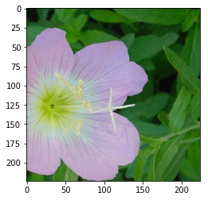

```python
## Let's test the two functions

image_path = 'flowers/train/1/image_06735.jpg'
image = Image.open(image_path)
processed_image = process_image(image)
imshow(processed_image)
```

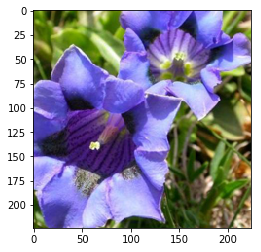

```python
image_path = 'flowers/test/28/image_05230.jpg'
image = Image.open(image_path)
processed_image = process_image(image)
imshow(processed_image)
```

## Class Prediction

Once you can get images in the correct format, it's time to write a function for making predictions with your model. A common practice is to predict the top 5 or so (usually called top-$K$) most probable classes. You'll want to calculate the class probabilities then find the $K$ largest values.

To get the top $K$ largest values in a tensor use [`x.topk(k)`](http://pytorch.org/docs/master/torch.html#torch.topk). This method returns both the highest `k` probabilities and the indices of those probabilities corresponding to the classes. You need to convert from these indices to the actual class labels using `class_to_idx` which hopefully you added to the model or from an `ImageFolder` you used to load the data (see here). Make sure to invert the dictionary so you get a mapping from index to class as well.

Again, this method should take a path to an image and a model checkpoint, then return the probabilities and classes.

```
probs, classes = predict(image_path, model)
print(probs)
print(classes)
> [ 0.01558163  0.01541934  0.01452626  0.01443549  0.01407339]
> ['70', '3', '45', '62', '55']
```

```python
def predict(image_path, model, topk=5):
    ''' Predict the class (or classes) of an image using a trained deep learning model.
    '''

    # TODO: Implement the code to predict the class from an image file

    ## We process the raw image
    image = Image.open(image_path)
    processed_image = process_image(image)
    image = torch.FloatTensor(processed_image)

    ## We move the image to the GPU if available
    image = image.to(device)
    image.unsqueeze_(0)

    ## We only want to predict, so we can disable dropout
    new_model.eval

    ## We apply our model on the image, and calculate the top probabilities
    log_output = model.forward(image)
    ps = torch.exp(log_output)
    top_ps, top_class = ps.topk(topk)

    ## Convert index to class
    idx_to_class = {}
    for key in class_to_idx.keys():
        idx_to_class[class_to_idx[key]] = key

    # Extract an array with the top labels
    ## Convert tensor to numpy array
    top_class = top_class.to('cpu')
    top_class = top_class.numpy()
    top_class = [idx_to_class[x] for x in top_class[0]]

    #Extract an array with the top probabilities
    top_ps = top_ps.to('cpu')
    top_ps = top_ps.numpy()
    top_ps = top_ps[0]

    return top_ps, top_class
```

```python
probs, classes = predict('flowers/train/1/image_06735.jpg', new_model)
print(probs)
print(classes)
```

```
[ 0.25527748  0.24951909  0.15289307  0.12909067  0.07009785]
['86', '1', '76', '83', '34']
```

## Sanity Checking

Now that you can use a trained model for predictions, check to make sure it makes sense. Even if the testing accuracy is high, it's always good to check that there aren't obvious bugs. Use `matplotlib` to plot the probabilities for the top 5 classes as a bar graph, along with the input image. It should look like this:

[figure not shown]

You can convert from the class integer encoding to actual flower names with the `cat_to_name.json` file (should have been loaded earlier in the notebook). To show a PyTorch tensor as an image, use the `imshow` function defined above.

```python
# TODO: Display an image along with the top 5 classes

def sanity_checking(image_path, model):

    ## First we load an image, process it to apply the model
    image = Image.open(image_path)
    processed_image = process_image(image)

    ## We calculate the top classes
    top_ps, top_class = predict(image_path, model)

    ## For each class, we extract the corresponding name
    top_class_names = []
    for item in top_class:
        top_class_names.append(cat_to_name[item])

    ## We prepare the plotting
    fig = plt.figure(figsize=(5, 10))
    axis_1 = plt.subplot(2,1,1)
    # The title of the image is the name of the flower with the highest probability
    image_title = axis_1.set_title(top_class_names[0])
    imshow(processed_image, axis_1, image_title)
    # We plot the graph of the probabilities
    axis_2 = plt.subplot(2,1,2)
    axis_2 = plt.yticks(range(5), top_class_names[::-1])
    axis_2 = plt.barh(range(5), top_ps[::-1])

    ## We render the plotting
    plt.show()
```

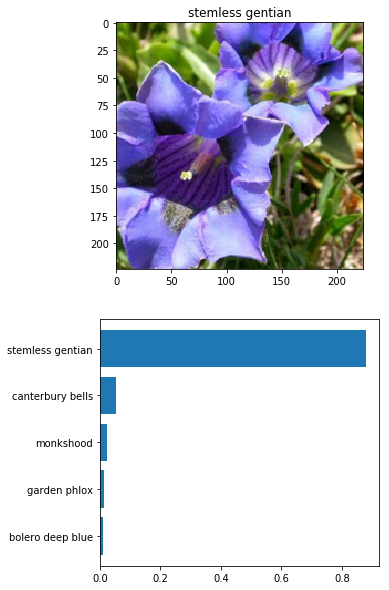

```python
## We test with one example
sanity_checking('flowers/test/28/image_05230.jpg',new_model)
```

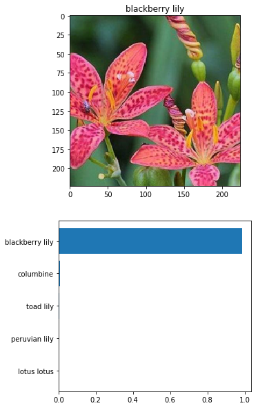

```python
sanity_checking('flowers/valid/102/image_08002.jpg',new_model)
```

```python
#Note:
    #The following resources have been used to build the code of this notebook.
    #https://github.com/fxzero/Flower-Image-Classifier/blob/master/Image%20Classifier%20Project.ipynb
    #https://github.com/rajesh-iiith/AIPND-ImageClassifier/blob/master/Image%20Classifier%20Project.ipynb
    #https://medium.com/@josh_2774/deep-learning-with-pytorch-9574e74d17ad
    #https://discuss.pytorch.org/t/expected-stride-to-be-a-single-integer-value-or-a-list/17612
    #https://discuss.pytorch.org/t/runtimeerror-expected-object-of-type-torch-floattensor-but-found-type-torch-cuda-floattensor-for-argument-2-weight/27483
```